# Linear Algebra Lecture 1: Review

In secondary schools we are introduced to 'word' problems to motivate the application of simulaneous equations.

Like the following:

#### Orla & Niamh

Oral has more money than Niamh.

- If Orla gives Niamh €25 they will have the same amount.
- If Niamh gives Orla €35 then Orla will have twice the amount Niamh is left with.

How much money do Orla and Niamh have?

#### Furniture Sale

- Modern package: 3-seater sofa + 2 seater sofa only €1300!
- Classic package: 3-seater sofa + 2 arm chairs only €1400!
- Starter package: 2-seater sofa + 1 arm chair only €800!

How much does each item cost on their own?

## Features of linear equations

1. Variables (unknowns) are multiplied by constants only. They are not multiplied by other variable(s).
2. Variables enter the equation linearly - they are not raised to a power, not an exponent to another number, not log transformed etc.
3. Linear combinations (additions) of the variables give a value.

## Some Applications

### Statistical Regression Modeling - Clinical Trial Data

|  | Response | Drug A | Drug B |
| --- | --- | --- | --- |
| 1 | 6.60 | 225.00 | 0.50 |
| 2 | 6.90 | 285.00 | 0.50 |
| 3 | 7.90 | 225.00 | 0.50 |
| 4 | 6.10 | 285.00 | 0.50 |
| 5 | 9.20 | 225.00 | 1.70 |
| 6 | 6.80 | 285.00 | 1.70 |
| 7 | 10.40 | 225.00 | 1.70 |
| 8 | 7.30 | 285.00 | 1.70 |
| 9 | 9.80 | 204.50 | 1.10 |
| 10 | 5.00 | 305.50 | 1.10 |
| 11 | 6.90 | 255.00 | 1.10 |
| 12 | 6.30 | 255.00 | 1.10 |
| 13 | 4.00 | 255.00 | 0.09 |
| 14 | 8.60 | 255.00 | 2.11 |
| 15 | 10.10 | 255.00 | 1.10 |
| 16 | 9.90 | 255.00 | 1.10 |
| 17 | 12.20 | 255.00 | 1.10 |
| 18 | 9.70 | 255.00 | 1.10 |
| 19 | 9.70 | 255.00 | 1.10 |
| 20 | 9.60 | 255.00 | 1.10 |

The model is:

Average Response for Drug A and Drug B doses = $$\beta_0 + \beta_1(Drug A) + \beta_2(Drug A)^2 + \beta_2(Drug B)+ \beta_4(Drug B)^2$$

This model gives a surface relationship which looks like the following picture:

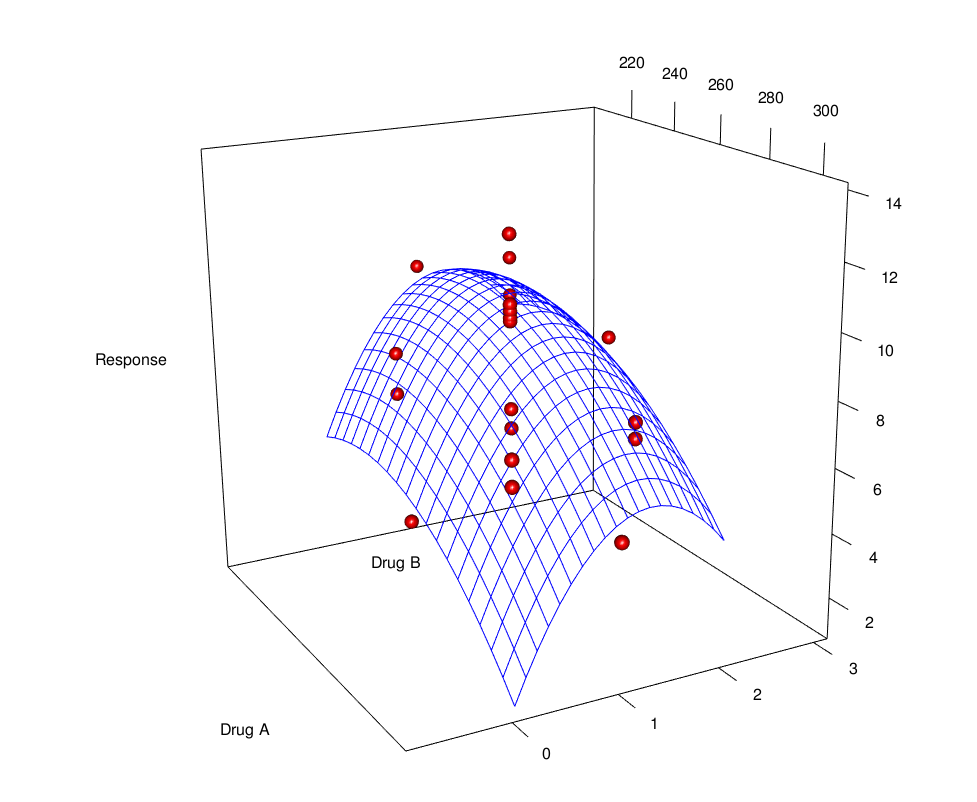

and this leads (after suitable formulation) to the following linear system:

$$\begin{bmatrix} 20 & 5100 & 1312800 & 22 & 29 \\ 5100 & 1312800 & 341037382 & 5610 & 7426 \\ 1312800 & 341037382 & 89383540125 & 1444081 & 1911017 \\ 22 & 5610 & 1444081 & 29 & 43 \\ 29 & 7426 & 1911017 & 43 & 68 \\ \end{bmatrix} \begin{bmatrix}\beta_0\cr \beta_1\cr\beta_2\cr \beta_3\cr\beta_4\end{bmatrix}= \begin{bmatrix} 163 \\ 41113 \\ 10461175 \\ 188 \\ 251 \end{bmatrix}$$

### Pagerank (Transition Matrix)

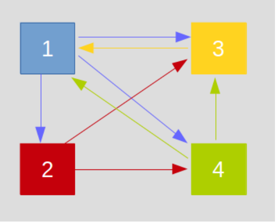

$$ A=\begin{bmatrix} 0 & 0.33333 & 0.33333 & 0.33333 \\ 0 & 0 & 0.5 & 0.5 \\ 1 & 0 & 0 & 0 \\ 0.5 & 0 & 0.5 & 0 \end{bmatrix}\\ \\ \\ \\ \Rightarrow A^{n}=\begin{bmatrix} 0.3871 & 0.12903 & 0.29032 & 0.19355 \\ 0.3871 & 0.12903 & 0.29032 & 0.19355 \\ 0.3871 & 0.12903 & 0.29032 & 0.19355 \\ 0.3871 & 0.12903 & 0.29032 & 0.19355 \end{bmatrix} $$

```matlab
A=[0, 1/3, 1/3, 1/3; 0, 0, 1/2, 1/2; 1, 0, 0, 0; 0.5, 0, 0.5, 0]
# A squared
A^2
# A raise to the 100th power
A^100
```

```
A =

   0.00000   0.33333   0.33333   0.33333
   0.00000   0.00000   0.50000   0.50000
   1.00000   0.00000   0.00000   0.00000
   0.50000   0.00000   0.50000   0.00000

ans =

   0.50000   0.00000   0.33333   0.16667
   0.75000   0.00000   0.25000   0.00000
   0.00000   0.33333   0.33333   0.33333
   0.50000   0.16667   0.16667   0.16667

ans =

   0.38710   0.12903   0.29032   0.19355
   0.38710   0.12903   0.29032   0.19355
   0.38710   0.12903   0.29032   0.19355
   0.38710   0.12903   0.29032   0.19355
```

## Introduction to matrix Algebra

$$ A=\begin{bmatrix} 1 & 2& 3\cr 4 & 4 & 7\cr 8 & 9 & 9 \end{bmatrix} \qquad B=\begin{bmatrix} 2 & 3& 0\cr 1 & 4 & 6\cr 5 & 6 & 7 \end{bmatrix} \qquad C=\begin{bmatrix} 1\cr 3\cr 5 \end{bmatrix} \qquad d=4 \qquad e=2 \qquad $$

**Terminology**

- dimension: the number of rows and columns in a matrix ($m\times n$)
- scalar: a single number, i.e. a $1\times 1$ 'matrix'
- vector: a 'matrix' where on dimension equals 1, ($1\times n$) [row vector] or ($m \times 1$) [column vector]
- matrix: a general rectangular ($m\times n$) array of numbers called entries, where for a matrix called $A$, each entry is denoted $a_{i,j}$, e,g, $a_{3,2}$ is the entry in row 3 and column 2.

**Basic rules**

- To add/subtract matrices they must have the same dimensions (match in terms of the number of rows and columns). Add/subtract corresponding entries.
- To multiple a matrix by a scalar, multiply each entry by that scalar.
- To multiply a matrix by a matrix (or vector), (a) the inner dimensions of the product must match (b) entries on row $i$ on the left matrix are multiplied by corresponding entries in column $j$ on the right matrix and summed to give the entry $i,j$ of the result.

Example 1.1  
Determine the following:

- scalar addition: $A+d$; $e+B$
- scalar multiplication: $e\times A$; $B\times d$
- addition of matrices: $A+B$; $B+C$; $B-A$
- multiplication of matrix: $A\times C$; $B\times A$

There are a few special matrices to note. The first one is the identity matrix, $I$. Often we will use a subscript like $I_n$ to specify its dimension.

$$ I_1 = \begin{bmatrix} 1 \end{bmatrix} \quad I_2 = \begin{bmatrix} 1 & 0 \cr 0 & 1 \end{bmatrix} \quad I_3 = \begin{bmatrix} 1 & 0 & 0 \cr 0 & 1 & 0 \cr 0 & 0 & 1\end{bmatrix} \quad $$

and so on.

Any matrix multiplied by the (conformable) identity matrix is itself - i.e. the identity plays the role of 1 in matrix algebra.

### Matrix formulation of linear systems

The definition of matrix multiplication gives a way of collecting the coefficients (multiples) of the variables of a linear system in a neat array (matrix).

E.G. Orla & Niamh: $$ \begin{bmatrix} 1 & -1\cr 1 & -2 \end{bmatrix}\begin{bmatrix} x \\ y \end{bmatrix}=\begin{bmatrix} 50 \\ -105 \end{bmatrix} $$

E.G. Furniture Sales?

## Gaussian Elimination

Consider a linear system in the following form: $$ Ax=b $$

Idea of Gaussian elimination: Use elementary row operations to reduce $A$ to **row echelon form**.

- Consider each row of $A$. Its first non-zero entry (left to right) should be 1 - the 'leading 1' principle.
  - Every entry directly below a leading one (i.e. in lower rows) should be zero. Therefore, leading 1's are always to the right of the leading one in the row above].
  - Any rows of all zeros are below rows with leading 1's.

### Elementary Row operations

These are used to reduced a coefficient matrix $A$ to row echelon form. They are:

- Multiple a row by a non-zero constant.
- Interchange (i.e. swap) two rows.
- Add one row (multiplied by a constant) to another row.

Example 1.2

Use these to reduce the coefficient matrix for the Furniture Sales system to row echelon form, and hence solve the system by back-substitution.

**Augmented Matrix**

Better to `carry' the RHS with you as you go!

Example 1.3

(a) Try the following augmented matrix approach. $$ \left[ \begin{array}{ccc|c} 1 & 1 & 0 & 1300\\ 1 & 0 & 2 & 1400\\ 0 & 1 & 1 & 800 \end{array} \right] $$

```matlab
% Using Octave
A=[1,1,0;1,0,2;0,1,1];
b=[1300;1400;800];
A\b;
```

(b) Now, do the same for the Orla & Niamh system.

(c) Another example

Solve the following system: $$ x +\ \ y + 2z = 9\\ 2x + 4y -3z = 1\\ 3x + 6y -5z = 0 $$

### Gauss-Jordan elimination

This is as before, but we include the backward substitution as part of the algorithm. Steps:

- proceed as before to reduce $A$ to row echelon form.
- Then, working from right to left, use backward elimination by applying elementary row operations to make zero all the entries directly above a leading one. This is called the **reduced row echelon form**.

If this works you should get something like this:

$$ \left[ \begin{array}{ccc|c} 1 & 0 & 0 & c_1\\ 0 & 1 & 0 & c_2\\ 0 & 0 & 1 & c_3 \end{array} \right]\quad \Rightarrow x=c_1, y=c_2, z=c_3 $$

Example 1.4  
Use this on: the Orla & Niamh system and the 'Another example' above.

### When things go 'wrong'

Three commonly met non-standard cases.

- Zero in the pivot position - i.e. leading zero. Solution is to **row exchange** if a non-zero is in the same position in a lower row.
- **Inconsistent system** - i.e. no solutions.
- **Free variable system** - infinite number of solutions.

### Row exchange

Example 1.5.1
Solve the following system using Gauss-Jordan. $$ \begin{array}{c@{} r@{\hspace{4pt}} c@{} r@{\hspace{4pt}} c@{\hspace{4pt}} r@{\hspace{4pt}} c@{\hspace{4pt}} r@{\hspace{4pt}} c@{\hspace{4pt}} r@{}} & x_1 & + & 2x_2 & + & 3x_3 & - & 4_4 &=& 5 \\ & 2x_1 & + & 4x_2 & + & 6x_3 & - & 6x_4 &=& 8 \\ & 0x_1 & - & 2x_2 & + & 4x_3 & + & 8x_4 &=& 12 \\ & 4x_1 & + & 0x_2 & + & 6x_3 & + & 6x_4 &=& 13 \\ \end{array} $$

### Inconsistent systems

Example 1.5.2

Solve the following systems.

system 1: $$ \begin{array}{c@{} r@{\hspace{4pt}} c@{\hspace{4pt}} r@{\hspace{4pt}} c@{\hspace{4pt}} r@{\hspace{4pt}} c@{\hspace{4pt}} r@{}} & x & + & 0y & - & z &=& 0\cr & -x & + & 0y & - & z &=& -2\cr & -x & + & 0y & - & 8z &=& 4 \end{array} $$

system 2: $$ \begin{array}{c@{} r@{\hspace{4pt}} c@{\hspace{4pt}} r@{\hspace{4pt}} c@{\hspace{4pt}} r@{\hspace{4pt}} c@{\hspace{4pt}} r@{}} & x & + & 2y & + & 3z &=& 5\cr & 4x & + & 8y & + & 9z &=& 7\cr & 8x & + & 16y & + & 12z &=& 12 \end{array} $$

system 3: $$ \begin{array}{c@{} r@{\hspace{4pt}} c@{\hspace{4pt}} r@{\hspace{4pt}} c@{\hspace{4pt}} r@{\hspace{4pt}} c@{\hspace{4pt}} r@{}} & x & + & 6y & + & 4z &=& 2\cr & 2x & + & 4y & - & z &=& 7\cr & -x & + & 2y & + & 5z &=& 8 \end{array} $$

#### Identifying Inconsistent Systems

When a linear system has no solutions we call it **inconsistent**.

Otherwise, the system is **consistent**.

We can identify such systems in a number of ways.

One way: If you perform elimination to the reduced row echelon form and we have all zeros on the left of the partition and a non-zero on the right.

### Free-variable systems: infinitely many solutions

Example 1.5.3

Solve the following systems:

system 1: $$ \begin{array}{c@{} r@{\hspace{4pt}} c@{\hspace{4pt}} r@{\hspace{4pt}} c@{\hspace{4pt}} r@{\hspace{4pt}} c@{\hspace{4pt}} r@{}} & x & + & 0y & - & z &=& 0\cr -& x & + & 0y & - & z &=& -2\cr & x & + & 0y & - & 4z &=& -3 \end{array} $$ system 2:

$$ \begin{array}{c@{} r@{\hspace{4pt}} c@{\hspace{4pt}} r@{\hspace{4pt}} c@{\hspace{4pt}} r@{\hspace{4pt}} c@{\hspace{4pt}} r@{}} & x & + & y & + & z &=& 7\cr & x & + & y & - & z &=& 5\cr -& x & - & y & + & z &=& -5 \end{array} $$

### Identifying the 3 cases

- No Solution: After reduction to RREF there is at least one row of all zeros left of the partition and a non-zero value on the right.
- Infinite number of solutions: (1) The system is consistent; (2) At least one column in the reduced system does not have a (non-zero) pivot. The variable corresponding to this column is a free variable and can be assigned any value.
- Unique solution: (1) The system is consistent; (2) A square system (discount any all zero rows); (3) All columns in the reduced system have non-zero pivots.

### Exercises 1.1

Give the augmented matrix for each of the following systems and solve the system (where possible). $$ \boxed{\begin{array}{c@{} r@{\hspace{4pt}} c@{\hspace{4pt}} r@{\hspace{4pt}} c@{\hspace{4pt}} r@{}} & 2x & - & y &=& 8\cr & 6x & - & 5y &=& 32\cr \end{array}} \qquad \qquad \qquad \boxed{\begin{array}{c@{} r@{\hspace{4pt}} c@{\hspace{4pt}} r@{\hspace{4pt}} c@{\hspace{4pt}} r@{}} & 4x & - & 3y &=& 10\cr & 8x & - & 1y &=& 10\cr \end{array}}$$

$$ \boxed{\begin{array}{c@{} r@{\hspace{4pt}} c@{\hspace{4pt}} r@{\hspace{4pt}} c@{\hspace{4pt}} r@{\hspace{4pt}} c@{\hspace{4pt}} r@{}} & 0x & + & y & + & z &=& 6\cr & 3x & - & y & + & z &=& -7\cr & x & + & y & - & 3z &=& -13 \end{array}}\qquad \boxed{\begin{array}{c@{} r@{\hspace{4pt}} c@{} r@{\hspace{4pt}} c@{\hspace{4pt}} r@{\hspace{4pt}} c@{\hspace{4pt}} r@{\hspace{4pt}} c@{\hspace{4pt}} r@{}} & 2x_1 & + & 3x_2 & + & 0x_3 & - & x_4 &=& 0 \\ & x_1 & + & x_2 & + & x_3 & - & 2x_4 &=& 7 \\ & 3x_1 & - & x_2 & + & 2x_3 & + & x_4 &=& -19 \\ & 2x_1 & - & 4x_2 & + & 3x_3 & + & 0x_4 &=& -12 \\ \end{array}} $$

## Matrix Inverse ($n\times n$)

If $A$ is an $(n\times n)$ matrix and another matrix $A^{-1}$ exists, satisfying: $$ A^{-1}A=I_n=AA^{-1} $$ we say that $A^{-1}$ is the inverse of $A$ and that $A$ is **non-singular (aka invertible)**.

NB: $A$ is the inverse of $A^{-1}$.

If no matrix $A^{-1}$ exists we say that $A$ is **singular** (non-invertible).

If $A$ is non-singular then the RREF can be found and there will be a unique solution to the system.

### Finding a matrix inverse

There are a number of methods. The most efficient (and easiest) is to use an elimination method.

Set up an augmented matrix: $$ S=[A|I_n] $$

Use row operations to convert the A part of the augmented matrix to a reduced row echelon form, carrying the right hand side of the augmented matrix along. If $A$ is non-singular you will end up with: $$ [A|I_n] \rightarrow [I_n|A^{-1}] $$

### Properties of the Matrix inverse

- If $A$ has a column or row of zeros then $A$ is singular.
- If $A^{-1}$ exists, then it is unique.
- If $A$ is non-singular, then the solution to a system $Ax=b$ is unique.

Q. When is a square matrix non-singular?

A. Perform elimination. If each column has a (non-zero) pivot - then the matrix is non-singular.

### Some examples of the rules in practice

Example 1.5.5

$$ A=\begin{bmatrix}0 & 1\cr 0 & 2\end{bmatrix} \qquad B=\begin{bmatrix}1 & 1\cr 3 & 4\end{bmatrix}\quad C=\begin{bmatrix}2 & 5\cr 3 & 4\end{bmatrix} $$

Find $AB$, $AC$, $B^{-1}AB$ and $A^{-1}AC$ - do not make the cancellation error here!

### More on Matrix Algebra

#### Matrix Transpose

Written as $A^{T}$ or $A'$ this where we exchange rows and columns.

e.g. Find the transpose of $A$:

$$ A=\begin{bmatrix} 1 & 1 & 2\cr 2 & 4 & -3\cr \end{bmatrix} \qquad \Rightarrow A'=? $$

Notice that $a_{ij}\rightarrow a_{ji}$

**Properties of Transpose**

- $[A']' = A$
- $[A+B]'=A'+B'$
- $[kA]'=kA'$ (for scalar $k$)
- $[AB]'=B'A'$

#### Trace of a square matrix

The trace of a square matrix is the sum of the components on the main diagonal.

e.g. Find the trace of $A$:

$$ A=\begin{bmatrix} 1 & 1 & 2\cr 2 & 4 & -3\cr 3 & 6 & -5 \end{bmatrix} \qquad \Rightarrow tr(A)=? $$

Properties of Trace:

- $tr[kA]=k tr[A]$
- $tr[A+B]=tr[A]+tr[B]$
- $tr[AB]=tr[BA]$
- $tr[ABC]=tr[BCA]=tr[CAB]\ne tr[ACB]$ (...in general) i.e. invariant to cyclical permutation of the product.

# Summary of some Matrix Algebra rules

- $A+B=B+A$
- $A+(B+C)=(A+B)+C$
- $AB\ne BA$ (...in general)
- $A(BC)=(AB)C$
- $A(B+C)=AB+AC$
- $(A-B)C=AC-BC$
- $k(A+B)=kA+kB$ (...scalar $k$)
- $(k-l)A=kA-lA$ (...scalar $k$ and $l$)
- $aBC=BaC=BCa$

**More results...**

$$ \begin{align*} &(AB)^{-1}=B^{-1}A^{-1} \qquad\mbox{(for $A$, $B$ both non-singular)}\\\\ &(A^{-1})^{-1}=A\cr\cr &A^n=A\times A\times ...\times A \qquad \mbox{($n$ terms)}\\\\ & (A^n)^{-1} = (A^{-1})^n\cr\cr & (kA)^{-1}=k^{-1}A^{-1}\\\\ & (A')^{-1}=(A^{-1})' \end{align*} $$

## # of solutions

- A system will have a unique solution if RREF is an identity matrix (ignore any `all zero' rows).
- The system will have no solution when the RREF reveals an inconsistent row(s).
- If a system is consistent and has more than one solution, then it must have an infinite number of solutions. [Proof?]

### Homogeneous Systems

Def; A homogeneous system satisfies the following:

$$ Ax=0 $$

where the RHS is a column vector of zeros.

- A homogeneous system cannot be inconsistent. [why?]
- If a homogeneous system has more than the trivial solution, then there are an infinity of solutions.
- If a homogeneous system $Ax=0$ has a non-trivial solution, then any corresponding inhomogeneous system $Ax=b$ will have a infinite number of solutions.
- A homogeneous system has more than the trivial solution if the number of unknowns exceeds the number equations (an **underdetermined** system) - therefore any **consistent** system with more unknowns than equations will have a infinite number of solutions.

## Pictures of Linear Systems

### Row view

Here we interpret each row as defining a line (2-D), plane (3-D) or hyperplane ($>$3D).

The intersection of the lines, planes or hyperplanes will be the solution to the system (may be a infinite number).

##### Row picture for Orla & Niamh

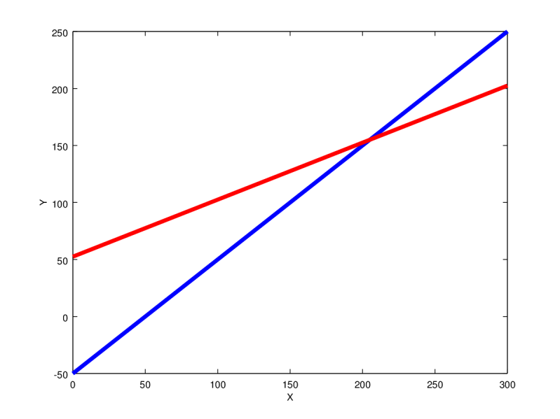

##### Row pictures of and Furniture Sales

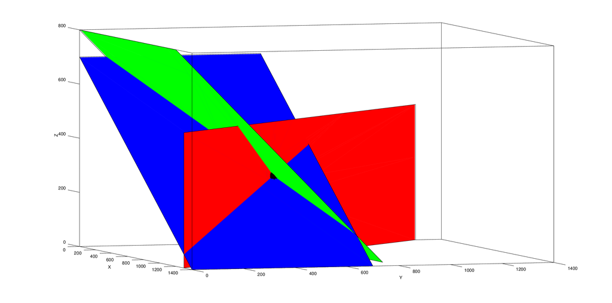

### Column view

Here, each column of a matrix represents a geometric vector in n-D space. The RHS of the system is the target, and we reach the target by taking a linear combination of the geometric vectors which are the columns of the coefficient matrix.

##### Column pictures of Oral & Niamh

The 'target' is the red coordinate vector $\begin{bmatrix}50 \\ -105\end{bmatrix}$

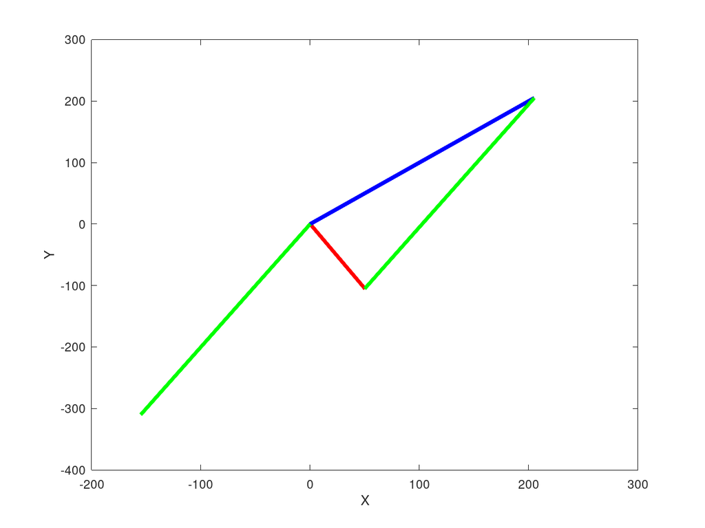

##### Column pictures of Furniture Sales

The 'target' is the red coordinate vector $\begin{bmatrix}1300 \\ 1400 \\ 800\end{bmatrix}$

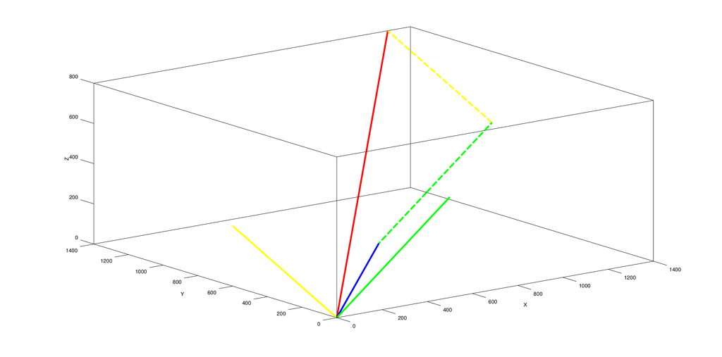

### Octave code to produce these pictures

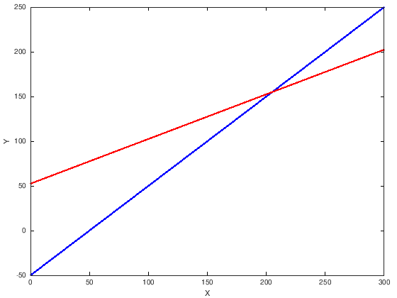

```matlab
%
%plot Row view orla & Niamh
%
x = 0:10:300;
plot(x, x-50,'color','b','linewidth',4)
xlabel('X');ylabel('Y');
line(x, (x+105)/2,'color','r','linewidth',4);
```

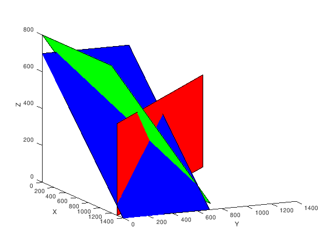

```matlab
%
% Furniture sale: row view
%
 %plot equation 1
 graphics_toolkit ("fltk");
 set(gcf,'Visible','on')
 x=[0 1300 1300 0]';
 y=[1300 0 0 1300]';
 z=[0 0 500 500]';
 patch(x,y,z,'red');
 view(-295,15)

 xlabel('X');
 ylabel('Y');
 zlabel('Z');
 hold;

  x=[0 0 1400 1400]';
 y=[0 700 700 0]';
 z=[700 700 0 0]';
 patch(x,y,z,'blue');
 hold;

  x=[0 1200 1200 0]';
 y=[0 0 800 800]';
 z=[800 800 0 0]';
 patch(x,y,z,'green');
hold;
```

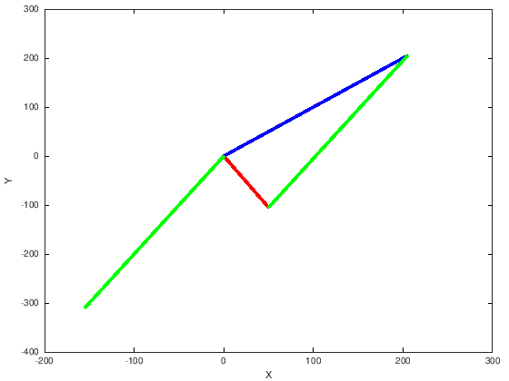

```matlab
graphics_toolkit ("gnuplot");
% vector plots
% Orla & Niamh column view
hold off;
plot([0 50],[0 -105],"linewidth",10,"color","red");
xlabel("X");ylabel("Y");
line([0 205],[0 205],"linewidth",10,"color","blue");
line([0 -155],[0 -310],"linewidth",10,"color","green");
line([205 50],[205 -105],"linewidth",10,"color","green","linestyle","-");
```

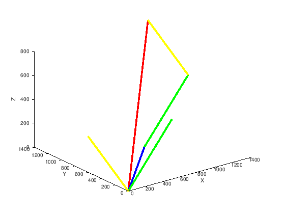

```matlab
% Furniture sale column view

hold off;
plot3([0 1300],[0 1400],[0 800],'linewidth',10,'color','red');
xlabel('X');ylabel('Y');zlabel('Z');
line([0 800],[0 800],[0, 0],'linewidth',10,'color','blue');
line([0 500],[0 0],[0 500],'linewidth',10,'color','green');
line([0 0],[0 600],[0 300],'linewidth',10,'color','yellow');
line([800 1300],[800 800],[0,500],'linewidth',10,'color','green');
line([1300 1300],[800 1400],[500,800],'linewidth',10,'color','yellow');
```

# Appendix: Some background extra information.

### Elimination & Matrix Algebra

Furniture Sales (coefficient matrix) $$ A=\left[ \begin{array}{ccc} 1 & 1 & 0 \\ 1 & 0 & 2 \\ 0 & 1 & 1 \end{array} \right] $$

### Elementary matrices

Define a elementary matrix as one which performs an elementary row operation by multiplying $A$ from the left (pre-multiplying). $$ \overbrace{\left[ \begin{array}{rrr} 1 & 0 & 0 \\ -1 & 1 & 0 \\ 0 & 0 & 1 \end{array} \right]}^{E_1} \overbrace{\left[\begin{array}{rrr} 1 & 1 & 0 \\ 1 & 0 & 2 \\ 0 & 1 & 1 \end{array} \right]}^{A}=? $$

What do the following do? $$ \overbrace{\left[ \begin{array}{rrr} 1 & 0 & 0 \\ 0 & -1 & 0 \\ 0 & 0 & 1 \end{array} \right]}^{E_2}, \qquad \overbrace{\left[ \begin{array}{rrr} 1 & 0 & 0 \\ 0 & 1 & 0 \\ 0 & -1 & 1 \end{array} \right]}^{E_3} $$

### Matrix Multiplication

Linear combinations of the columns in matrix on left. $$ \overbrace{\left[ \begin{array}{rrr} a_{11} & a_{12} & a_{13} \\ a_{21} & a_{22} & a_{23} \\ a_{31} & a_{32} & a_{33} \\ \end{array} \right]}^{A} \overbrace{\left[ \begin{array}{rrr} b_{1} \\ b_{2} \\ b_{3} \\ \end{array} \right]}^{B}=b_1 \vec{a}_{.1} +b_2 \vec{a}_{.2}+ b_3 \vec{a}_{.3} $$

Linear combinations of rows in matrix on right. $$ \overbrace{\left[ \begin{array}{rrr} b_{1} & b_{2} & b_{3} \end{array} \right]}^{B} \overbrace{\left[ \begin{array}{rrr} a_{11} & a_{12} & a_{13} \\ a_{21} & a_{22} & a_{23} \\ a_{31} & a_{32} & a_{33} \\ \end{array} \right]}^{A} =b_1 \vec{a}_{1.} +b_2 \vec{a}_{2.}+ b_3 \vec{a}_{3.} $$

### Combining Elementary matrices

Find all the elementary matrices to solve the furniture sales problem.

Combine them into one matrix using matrix multiplication - call this matrix $E$.

Determine $EA$ and $Eb$ what do you notice?

NB: $$\begin{align*} EA=I \mbox{ and } AE=I &\Rightarrow E=A^{-1}\\\\ \mbox{Therefore } Ax=b &\Rightarrow EAx=Eb \\\\ &\Rightarrow A^{-1}Ax=A^{-1}b \\\\ &\Rightarrow Ix=A^{-1}b \\\\ &\Rightarrow x=A^{-1}b \end{align*}$$

### Finding the matrix inverse (Yet...) Another view of matrix multiplication.

Consider the following partition of matrix $B$ into two parts; $B_1$ and $B_2$.

$$ \left[ \begin{array}{rrr} a_{11} & a_{12} & a_{13} \\ a_{21} & a_{22} & a_{23} \\ a_{31} & a_{32} & a_{33} \\ \end{array} \right] \left[ \begin{array}{rr | r} b_{11} & b_{12} & b_{13} \\ b_{21} & b_{22} & b_{23} \\ b_{31} & b_{32} & b_{33} \\ \end{array} \right]=\left[\overbrace{AB_1}^{3\times 2} | \underbrace{A{B_2}}_{3\times 1}\right] $$

This suggest a Gauss-Jordan algorithm for finding an inverse: $$ E[A | I] = [EA | EI] = [A^{-1}A | A^{-1}I] = [I | A^{-1}] $$

Also, from before we had: $$ E[A | b] = [EA | Eb] = [A^{-1}A | A^{-1}b] = [I | x] $$

Find the inverse of the coefficient matrix in the following system and hence solve the system. $$\begin{align*} x +\ \ y + 2z &= 9\\ 2x + 4y -3z &= 1\\ 3x + 6y -5z &= 0 \end{align*}$$

If the RHS changed to: $$ \begin{bmatrix}2\\ 14\\ 9\end{bmatrix} $$ what would the solution be?